# Интерполяция

## Задача интерполяции

Пусть задана некоторая сетка $x_i$, $i = 0..N$ и на ней задана сеточная функция $f_i = f(x_i)$. Задача интерполяции состоит в том, чтобы восстановить значения функции вне заданных узлов. Для этого строится непрерывная функция. Восстановление значений происходит на интервале $(x_0, x_N)$. Если нужно доопределить функцию вне этого интервала, то речь идет уже о задаче экстраполяции.

$$ f_i \xrightarrow{Интерполяция} P(x) $$

При этом, необходимо выполнение **основного условия интерполяции**

$$ f(x_i) = P(x_i) $$

### Виды интерполяции

Интерполяция может быть

- алгебраической: $P(x)$ — многочлен некоторой степени $$ P(x) = a_0 + a_1 x + a_2 x^2 + a_3 x ^3 + a_4 x^4 \dots $$
- тригонометрической: $P(x)$ — тригонометрический многочлен $$ P(x) = a_0 + a_1 \cos x + b_1 \sin x + a_2 \cos 2x + b_2 \sin 2x \dots $$

### Построение путем сведения к СЛАУ

Рассмотрим алгебраическую интерполяцию. Можно потребовать выполнение основного условия интерполяции. Тогда интерполяционный полином можно построить на основе решения системы линейных алгебраических уравнений (СЛАУ). $$ P(x_0) = a_0 + a_1 x_0 + a_2 x_0^2 + \dots = f(x_0)\\ P(x_1) = a_0 + a_1 x_1 + a_2 x_2^1 + \dots = f(x_1)\\ \vdots\\ P(x_n) = a_0 + a_1 x_n + a_2 x_n^2 + \dots = f(x_n) $$

Неизвестными параметрами интерполирующего многочлена $P(x)$ являются его коэффициенты. Относительно них система является линейной и разрешима. В этом случае степень полинома **на 1 меньше**, чем число узлов (это логично: через 2 точки можно провести единственную прямую, через три точки - единственную параболу и т.д.).

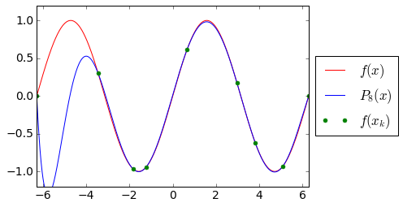

```python
import numpy as np
import matplotlib.pyplot as plt
%matplotlib inline
plt.rc('font', **{'size' : 14})

n = 9
h = 0.2 + np.random.rand(n)
x = np.cumsum(h)
x -= x[0]
x /= x[-1]
a = 2 * np.pi
x = a * (2 * x - 1)

def f(x):
    return np.sin(x)
fv = f(x)

W = np.empty((n, n))
for k in range(n):
    W[:, k] = x**k
c = np.linalg.solve(W, fv)

X = np.linspace(-a, a, 1000)
P = lambda x: np.polyval(list(reversed(c)), x)

plt.plot(X, f(X), 'r', label='$f(x)$')
plt.plot(X, P(X), 'b', label='$P_{%d}(x)$' % (n-1))
plt.plot(x, fv, 'g.', ms=10, label='$f(x_k)$')
plt.axis([-a, a, -1.2, 1.2])
plt.legend(loc='center left', bbox_to_anchor=(1, 0.5))
plt.show()
```

### Способы построение интерполяционного многочлена

Существуют способы построение интерполяционного многочлена, не требующие решения системы линейных уравнений

- Интерполяционный полином в форме Ньютона
- Интерполяционный полином в форме Лагранжа
- Интерполяционный полином в форме Чебышева
- и др.

При этом интерполяционный многочлен остается одним и тем же (он единственный!), изменяется лишь форма его представления и метод построения.

## Метод Ньютона

### Разделенные разности

Разделенной разностью первого порядка называется велчина: $$ f_{ij} = f(x_i, x_j) = \frac{f_i - f_j}{x_i - x_j} $$

Разделенной разностью второго порядка называют "разницу разниц первого порядка":

$$ f_{ijk} = f(x_i, x_j, x_k) = \frac{f_{ij} - f_{jk}}{x_i - x_k} $$

Порядком разделенной разности $f(x_i, \dots, x_{i+k})$ называется число аргументов без единицы ($k$). Разделенные разности нулевого порядка $f_i=f(x_i)$ совпадают со значениями функции $f(x_i)$ (путаницы в обозначениях нет)

Разделенная разность порядка $k+1$ определяется через разделенные разности порядка $k$: $$ f(\color{red}{x_{i}}, \dots, \color{blue}{x_{i+k+1}}) = \frac{f(x_{i+1}, \dots, \color{blue}{x_{i+k+1}}) - f(\color{red}{x_{i}}, \dots, x_{i+k})}{\color{blue}{x_{i+k+1}} - \color{red}{x_{i}}} $$

Разделенные разности удобно вычислять в таблице, например так:

| $x_i$ | $f(x_i)$ | $f(x_i, x_{i+1})$ | $f(x_i, x_{i+1}, x_{i+2})$ |
| --- | --- | --- | --- |
| $1$ | $\color{red}{1}$ |  |  |
|  |  | $\color{green}{2}$ |  |
| $2$ | $3$ |  | $\color{blue}{-1}$ |
|  |  | $-1$ |  |
| $4$ | $1$ |  |  |

$$ P(x) = \color{red}{1} + \color{green}{2} (x - 1) \color{blue}{-1} (x-1)(x-2) $$

```python
def divided_differences(x, f):
    n = len(x);
    F = np.empty((n, n))
    F[:, 0] = f
    for k in range(1, n):
        F[0:n-k, k] = (F[1:n-k+1, k-1] - F[0:n-k, k-1]) / (x[k:] - x[:-k])
    return F # F[i, k] = f(x_i, x_{i+1}, ..., x_{i+k})

x = np.array([1, 2, 4, 5])
f = np.array([1, 3, 1, 3])
F = divided_differences(x, f)
print(F)
```

```
[[  1.00000000e+000   2.00000000e+000  -1.00000000e+000   5.00000000e-001]
 [  3.00000000e+000  -1.00000000e+000   1.00000000e+000   1.73383010e-316]
 [  1.00000000e+000   2.00000000e+000   6.91364661e-310   0.00000000e+000]
 [  3.00000000e+000   6.91364663e-310   0.00000000e+000   0.00000000e+000]]
```

### Интерполяционный полином в форме Ньютона

Интерполяционный многочлен в форме Ньютона строится с помощью конечных разностей и имеет вид $$ P_{n-1}(x) = f(x_1) + f(x_1, x_2) (x - x_1) + f(x_1, x_2, x_3) (x - x_1) (x - x_2) + \dots \\ \dots + f(x_1, \dots, x_n) (x - x_1) \cdots (x - x_{n-1}) $$

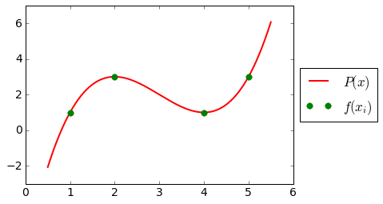

```python
def evaluate(x, F, x0):
    n = len(x);
    P = 0;
    xprod = 1.0 # (x - x1) (x - x2) ... (x - xi)
    for i in range(n):
        P += F[0, i] * xprod
        xprod *= (x0 - x[i])
    return P

X = np.linspace(0.5, 5.5, 1000)
plt.plot(X, evaluate(x, F, X), 'r', lw=2, label='$P(x)$')
plt.plot(x, f, 'g.', ms=15, label='$f(x_i)$')
plt.legend(loc='center left', bbox_to_anchor=(1, .5)); plt.show()
```

## Метод Лагранжа

Рассмотрим вспомогательную задачу. Построим интерполяционный многочлен для функции $f_k(x_i) = \delta_{ik} = \begin{cases}1, &x_i = x_k\\ 0, &x_i \neq x_k\end{cases}$

Этот многочлен имеет вид $$ \ell_k(x) = \frac{(x - x_1)\cdots(x-x_{k-1})(x-x_{k+1}) \cdots (x-x_n)}{ (x_k - x_1)\cdots(x_k-x_{k-1})(x_k-x_{k+1}) \cdots (x_k-x_n) } = \prod_{i\neq k}\frac{x-x_i}{x_k-x_i} $$ Данный многочлен называется *базисным интерполяционным многочленом Лагранжа*

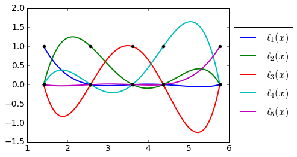

```python
n = 5
x = np.cumsum(0.5 + np.random.rand(n))
X = np.linspace(x[0], x[-1], 1000)
for i in range(n):
    v = np.eye(n)[i]
    F = divided_differences(x, v)
    plt.plot(X, evaluate(x, F, X), label='$\ell_{%d}(x)$' % (i+1), lw=2)
    plt.plot(x, v, 'k.', ms=10)
plt.legend(loc='center left', bbox_to_anchor=(1, .5)); plt.show()
```

### Интерполянт в форме Лагранжа

После построения базисных интерполяционных многочленов интерполянт записывается особенно просто $$ P(x) = \sum_{k=1}^n f(x_k)\ell_k(x) $$ Хорошо видно, что от $x$ зависят лишь базисные многочлены, а от $f$ — лишь коэффициенты разложения по этим многочленам.

#### Задача 1

Построить интерполяционный многочлен степени не выше 3 в форме Лагранжа, Ньютона и с помощью решения СЛАУ для сеточной функции

| $t_i$ | -3 | -2 | -1 | 0 |
| --- | --- | --- | --- | --- |
| $f(t_i)$ | 16 | 7 | 4 | 1 |

#### Решение

По 4-м точкам можно построить единственную кривую 3-й степени: $P_N(t) = a_0 + a_1 t + a_2 t^2 + a_3 t^3$.

1. Пользуясь основным условием интерполяции $P_N(t_i) = f(t_i)$ можно составить систему линейных уравнений:

$$ a_0 + (- 3) a_1 + (-3)^2 a_2 + (-3)^3 a_3 = 16 $$$$ a_0 + (- 2) a_1 + (-2)^2 a_2 + (-2)^3 a_3 = 7 $$$$ a_0 + (- 1) a_1 + (-1)^2 a_2 + (-1)^3 a_3 = 4 $$$$ a_0 = 1 $$

Откуда следует, что $a_0 = 1, a_1 = -5, a_2 = -3, a_3 = -1$, таким образом, $P_3(t) = 1 - 5t - 3t^2 - t^3$

1. Воспользуемся методом Лагранжа. Сначала построим базисные функции

$$ \phi_0^3 = \frac{(t - t_1)(t - t_2)(t - t_3)}{(t_0 - t_1)(t_0 - t_2)(t_0 - t_3)}=\frac{t(t + 1)(t + 2)}{-6} $$$$ \phi_1^3 = \frac{(t - t_0)(t - t_2)(t - t_3)}{(t_1 - t_0)(t_1 - t_2)(t_1 - t_3)}=\frac{t(t + 1)(t + 3)}{2} $$$$ \phi_2^3 = \frac{(t - t_1)(t - t_0)(t - t_3)}{(t_2 - t_1)(t_2 - t_0)(t_2 - t_3)}=\frac{t(t + 2)(t + 3)}{-2} $$$$ \phi_3^3 = \frac{(t - t_1)(t - t_2)(t - t_0)}{(t_3 - t_1)(t_3 - t_2)(t_3 - t_0)}=\frac{(t + 1)(t + 2)(t + 3)}{6} $$

Тогда интерполяционный многочлен в форме Лагранжа:

$$ L_3(t)=\Sigma_{i}{f_i\phi_i}=16\frac{t(t+1)(t+2)}{-6}+7\frac{t(t+1)(t+3)}{2}+4\frac{t(t+2)(t+3)}{-2}+\frac{(t+1)(t+2)(t+3)}{6} $$

1. Интерполяционный полином в форме Ньютона

| $t_i$ | $f_i$ | $f_{i,i+1})$ | $f_{i,i+1,i+2}$ | $f_{i,i+1,i+2,i+3}$ |
| --- | --- | --- | --- | --- |
| $-3$ | $\color{red}{16}$ |  |  |  |
|  |  | $\frac{16-7}{-3+2}= \color{red}{- 9} $ |  |  |
| $-2$ | $7$ |  | $\frac{-9+3}{-3+1}= \color{red}{ 3} $ |  |
|  |  | $\frac{7-4}{-2+1}= - 3 $ |  | $\frac{3+0}{-3+0}= \color{red}{-1} $ |
| $-1$ | $4$ |  | $0$ |  |
|  |  | $\frac{4-1}{-1+0}= - 3 $ |  |  |
| $0$ | $1$ |  |  |  |

Тогда полином составляется в виде: $$ P_3(t) = 16 -9 (t +3) + 3 (t+3)(t+2) -(t+3)(t+2)(t+1) $$

### Ошибка интерполяции

Важный вопрос — насколько $P(x)$ и $f(x)$ различаются? Очевидно, что в узлах $x_k$ они совпадают, но что происходит в промежутках?

Верна теорема $$ |f(x) - P(x)| \leqslant \frac{|f^{(n)}(\xi)|}{n!} |\omega(x)|, $$ где $$ \omega(x) = (x - x_1) (x - x_2) \cdots (x - x_n). $$

Величина, равная модулю разницы функции и ее интерполянта называется **остаточным членом интерполяции** $$ R_N(x) = |f(x) - P(x)| \leqslant \frac{|f^{(n)}(\xi)|}{n!} |\omega(x)|,\\ \omega(x) = (x - x_1) (x - x_2) \cdots (x - x_n), $$

Первый сомножитель можно оценить как $\frac{M_n}{n!}$, то есть величиной, зависящей лишь от функции, а второй сомножитель $|\omega(x)|$ зависит лишь от расположения узлов, но не от самой функции. Тогда ошибка интерполяции:

$$ \varepsilon_\text{метод} =\max_{x}{|R_N(x)|} =|f(x) - P(x)| = \frac{M_N}{n!} \max_{x}{|(x - x_1) (x - x_2) \cdots (x - x_n)|}, $$

### Задача 2

Оценить погрешность интерполяции функции $f(t) = \cos t$ на отрезке $t \in [0, \frac{\pi}{2}]$ по 3-м равноотстоящим точкам.

Решение: $$ M_3 = \max_{\xi \in [0, \frac{\pi}{2}] } {|f'''(\xi)|} = \max_{\xi \in [0, \frac{\pi}{2}] } {\cos \xi}=1 $$

Тогда можно определить ошибку как

$$ \Delta = \frac {M_3}{3!} \max_{t \in [0, \frac{\pi}{2}] } {(t - t_0)(t - t_1)(t - t_2)} = \frac{1}{3!}\max_{t \in [0, \frac{\pi}{2}]} {|t(t - \frac{\pi}{4})(t - \frac{\pi}{2})|} $$

Рассмотрим отдельно полиномиальное слагаемое $$ t(t - \frac{\pi}{4})(t - \frac{\pi}{2}) = t^3 - \frac{3\pi}{4}t^2 + \frac{\pi^2}{8}t $$ Найдем такое значение аргумента, при котором это выражения становится максимальным. Для этого определим экстремум полинома:

$$ \frac{d(t^3 - \frac{3\pi}{4}t^2 + \frac{\pi^2}{8}t)}{dt} = 3t^2 - \frac{3\pi}{2} + \frac{\pi^2}{8} = 0 $$

В силу симметричности полинома относительно оси $ t = 0$ в качестве точки экстремума можно взять $t^* = \frac{\pi}{4} + \frac {\sqrt{3}}{6}\pi$

Отсюда получаем, что $$ \frac{1}{3!}\max_{t \in [0, \frac{\pi}{2}]} {|t(t - \frac{\pi}{4})(t - \frac{\pi}{2})|} = t^*(t^* - \frac{\pi}{4}) (t^* - \frac{\pi}{2}) = \frac{\pi^3 \sqrt{3}} { 48* 6} $$

### Феномен Рунге

Оказывается, что увеличение количества узлов интерполяции не гарантирует улучшения приближения функции. Пример $$ f(x) = \frac{1}{1 + 25 x^2}, \qquad x \in [-1, 1] $$ Будем проводить интерполяцию этой функции на равномерной сетке с числом узлов $n = 5, 10, 15, 20$

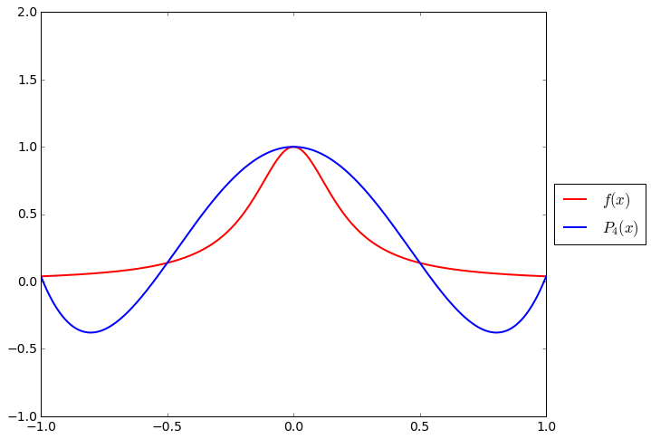

```python
def runge(x):
    return 1 / (1 + 25 * x**2)

X = np.linspace(-1, 1, 1000)

plt.figure(figsize=(10, 8))
plt.plot(X, runge(X), 'r', label='$f(x)$', lw=2)
n = 5
x = np.linspace(-1, 1, n)
F = divided_differences(x, runge(x))
plt.plot(X, evaluate(x, F, X), label='$P_{%d}(x)$' % (n-1), lw=2)
plt.axis([-1, 1, -1, 2]);
plt.legend(loc='center left', bbox_to_anchor=(1, .5)); plt.show()
```

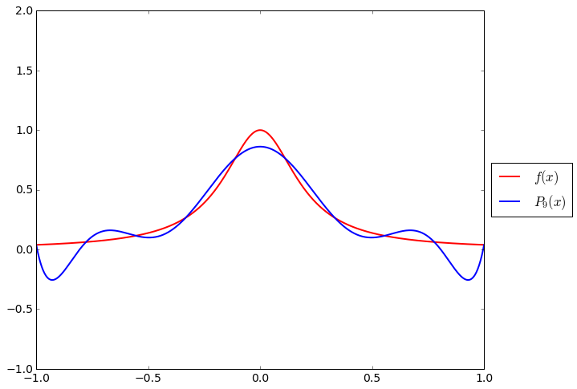

```python
plt.figure(figsize=(10, 8))
plt.plot(X, runge(X), 'r', label='$f(x)$', lw=2)
n = 10
x = np.linspace(-1, 1, n)
F = divided_differences(x, runge(x))
plt.plot(X, evaluate(x, F, X), label='$P_{%d}(x)$' % (n-1), lw=2)
plt.axis([-1, 1, -1, 2]);
plt.legend(loc='center left', bbox_to_anchor=(1, .5)); plt.show()
```

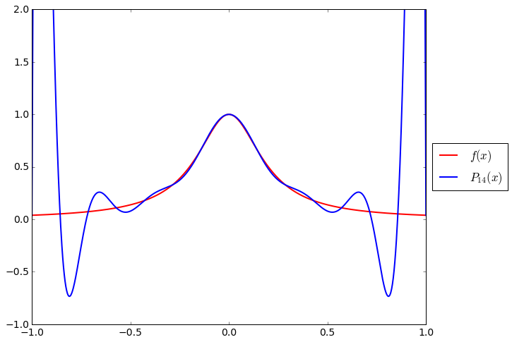

```python
plt.figure(figsize=(10, 8))
plt.plot(X, runge(X), 'r', label='$f(x)$', lw=2)
n = 15
x = np.linspace(-1, 1, n)
F = divided_differences(x, runge(x))
plt.plot(X, evaluate(x, F, X), label='$P_{%d}(x)$' % (n-1), lw=2)
plt.axis([-1, 1, -1, 2]);
plt.legend(loc='center left', bbox_to_anchor=(1, .5)); plt.show()
```

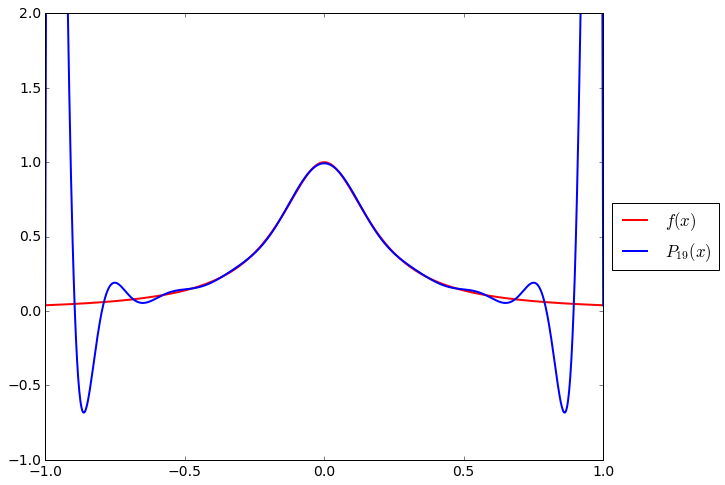

```python
plt.figure(figsize=(10, 8))
plt.plot(X, runge(X), 'r', label='$f(x)$', lw=2)
n = 20
x = np.linspace(-1, 1, n)
F = divided_differences(x, runge(x))
plt.plot(X, evaluate(x, F, X), label='$P_{%d}(x)$' % (n-1), lw=2)
plt.axis([-1, 1, -1, 2]);
plt.legend(loc='center left', bbox_to_anchor=(1, .5)); plt.show()
```

### Задача 3

Определить минимальное число узлов интерполяции на равномерной сетке, чтобы на отрезке $t \in [0, \frac{\pi}{2}]$ функция $f(t) = \cos t$ приближалась с точностью $\epsilon = 10^{-3}$

Решение: Основная сложность при решении задачи заключается в определеннии полиномиального сомножителя $$ \max_{t \in [a, b] } |{(t - t_0)(t - t_1)...(t - t_N)}| $$ в общем виде. На равномерной сетке с шагом $h$ с достаточно болшой точностью максимум модуля достигается при $t = a + \frac{h}{2} = t_0 + \frac{h}{2}$

Тогда $$ \max_{t \in [a, b] } |{(t - t_0)(t - t_1)...(t - t_N)}| \approx |(t_0 + \frac{h}{2} - t_0)(t_0 + \frac{h}{2} - t_1)...(t_0 + \frac{h}{2} - t_N)| = |\frac{h}{2}(-\frac{h}{2})(\frac{3h}{2})...(\frac{-(2N-1)h}{2})|<h \cdot h \cdot 2h \cdot 3h \cdot...\cdot Nh = N! h^{N+1} $$

Таким образом справедлива следующая оценка

$$ \max_{t \in [a, b] } |R_N(t)|<\frac {\max_{t \in [a, b] } |f^{N+1}(\xi)|}{(N+1)!}N!h^{N+1} = \frac{M_{N+1}}{N+1} h^{N+1} $$

В нашем случае $M_{N+1} = 1$, поэтому необходимо определить $N$, при котором $$ \epsilon \geq \frac{h^{N+1}}{N+1} = \frac{1}{N+1}(\frac{(\pi)}{2N})^{N+1} = \frac{1}{N+1} (\frac{\pi}{2N})^{N+1} $$

где шаг равномерной сетки $h = \frac{b-a}{N} = \frac{\pi}{2N}$

Последняя задача обычно решается перебором целвых значений $N$. В частности для текущей постановки задачи неравенство выполняется для $N \geq 5$. То есть, минимальное число точек $N+1 = 6$.

### Задача 4

Сравнить погрешности линейной интерполяции функции $ f(t) = \cos t$ с погреностью квадратичной интерполяции.

Решение: Для квадратичной интерполяции мы получали в Задаче 2, что $$ \Delta_{кв} = \frac{1}{3!}\max_{t \in [0, \frac{\pi}{2}]} {|t(t - \frac{\pi}{4})(t - \frac{\pi}{2})|} = t^*(t^* - \frac{\pi}{4}) (t^* - \frac{\pi}{2}) = \frac{\pi^3 \sqrt{3}} { 48* 6} \approx 0.186474 $$

Похожим образом оценим линейную интерполяцию:

$$ \Delta_{лин} = \frac{M_2}{2!}\max_{t \in [0, \frac{\pi}{2}]}{|(t - t_0)(t - t_1)|} $$

В случае погрешности мы получаем, что остаточный член интерполяции зависит от $t$ квадратичным способом и максимум находится в центре симметрии параболы. Тогда, учитывая, что в условиях задачи $M_2 = 1$

$$ \Delta_{лин} = \frac{1}{2}\max_{t \in [0, \frac{\pi}{2}]}{|t(t - \frac{\pi}{2})|}= \frac{1}{2} (\frac{\pi}{4})^2 \approx 0.308 $$

### Оптимальное расположение узлов

Изучим, насколько сильно можно уменьшить ошибку интерполяции, если грамотно выбирать узлы интерполяции.

Рассмотрим функцию $\omega(x) = (x - x_1) \cdots (x - x_n)$. На равномерной сетке она сильно растет к краям отрезка:

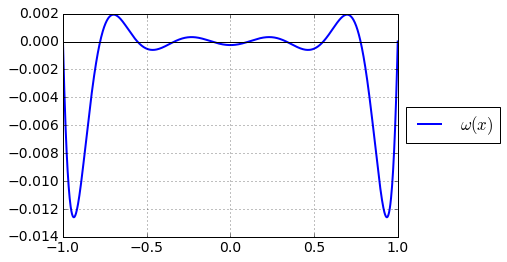

```python
X = np.linspace(-1, 1, 1000)
x = np.linspace(-1, 1, 10)
omega = (X - x[0]);
for i in range(1, len(x)):
    omega *= (X - x[i])
plt.plot(X, omega, 'b', lw=2, label='$\omega(x)$')
plt.plot(X, 0*X, 'k')
plt.grid()
plt.legend(loc='center left', bbox_to_anchor=(1,.5)); plt.show()
```

### Чебышевские узлы

Из приведенных примеров видно, что существенный вклад в погрешность метода делает полиномиальный сомножитель. Неполиномиальная часть погрешности зависит только от свойств интерполируемой функции и количества узлов интерполяции, величина же максимального значения модуля полинома определяется самими узловыми точками интерполяции. Таким образом, выбор расположения узлов может повлиять на величину погрешности интерполяции. Другими словами требуется найти полном степени $N + 1$ , наименее уклоняющийся от нуля. Тогда нули это полинома и будут оптимальными узлами интерполяции с точки зрения погрешности.

$$ T_N(x) = (x - x_0)(x - x_1) ... (x - x_N) $$

Такой полином существует, это полином Чебышева. Его запись в явном виде:

$$ T_N(x) = \cos (N \arccos x)) x \in[-1, 1] $$

В рекурентном виде:

$$ T_0(x)= 1, T_1(x) = x, T_{n+1} = 2x \cdot T_n(x) - T_{n-1}(x) $$

В некоторых приложениях используются нормированные полиномы Чебышева $$ \overline T_0(x)= 1, \overline T_{n} = T_n(x) / 2^{n-1} $$

И приведенные полиномы Чебышева

$$ \widetilde T_0(x)= \frac{1}{\sqrt{2}}, \widetilde T_{n} = T_n(x) $$

[output not shown]

В таком случае,в качестве узлов интерполяции берутся нули полином Чебышева $t_k = x_k$ , которые легко можно получить, приравняв полином нужной степени к нулю. Для полинома степени $N + 1$ нули на отрезке $x \in [-1, 1]$ Получаем:

$$ x_n = \cos{\frac{2n+1}{2(N+1)}\pi}, n = 0..N $$

Если интерполяцию необходимо сделать на отрезке $[a, b]$, то для построения Чебышевской стеки нужно сделать линейное преобразование $$ x_k = \frac{a+b}{2} + \frac{b-a}{2} \cos\left(\frac{2k-1}{2Т+2}\pi\right), $$ Сетка, построенная на экстремумах полиномов Чебышева обладает такими же свойчствами. Посмотрим, как ведет себя полином Чебышева.

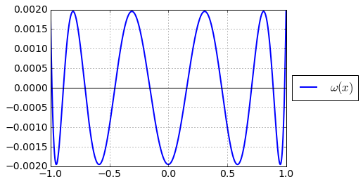

```python
X = np.linspace(-1, 1, 1000)
x = np.cos((2*np.arange(10)+1) / 20 * np.pi)
omega = (X - x[0]);
for i in range(1, len(x)):
    omega *= (X - x[i])
plt.plot(X, omega, 'b', lw=2, label='$\omega(x)$')
plt.plot(X, 0*X, 'k')
plt.grid()
plt.legend(loc='center left', bbox_to_anchor=(1,.5)); plt.show()
```

Доказано, что в случае выбра Чебышевских узлов интерполяции последовательность интерполяционных многочленов $P_n(x)$ будет сходиться к $f(x)$ *равномерно*, если $f(x)$ имеет ограниченную первую производную.

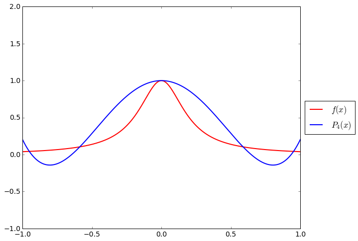

```python
def runge(x):
    return 1 / (1 + 25 * x**2)

X = np.linspace(-1, 1, 1000)

plt.figure(figsize=(10, 8))
plt.plot(X, runge(X), 'r', label='$f(x)$', lw=2)
n = 5
x = np.cos((np.arange(n)*2+1) / (2*n) * np.pi)
F = divided_differences(x, runge(x))
plt.plot(X, evaluate(x, F, X), label='$P_{%d}(x)$' % (n-1), lw=2)
plt.axis([-1, 1, -1, 2]);
plt.legend(loc='center left', bbox_to_anchor=(1, .5)); plt.show()
```

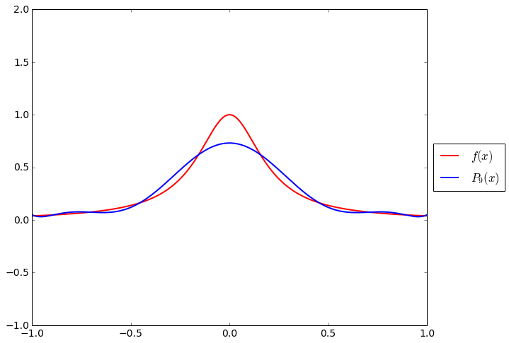

```python
plt.figure(figsize=(10, 8))
plt.plot(X, runge(X), 'r', label='$f(x)$', lw=2)
n = 10
x = np.cos((np.arange(n)*2+1) / (2*n) * np.pi)
F = divided_differences(x, runge(x))
plt.plot(X, evaluate(x, F, X), label='$P_{%d}(x)$' % (n-1), lw=2)
plt.axis([-1, 1, -1, 2]);
plt.legend(loc='center left', bbox_to_anchor=(1, .5)); plt.show()
```

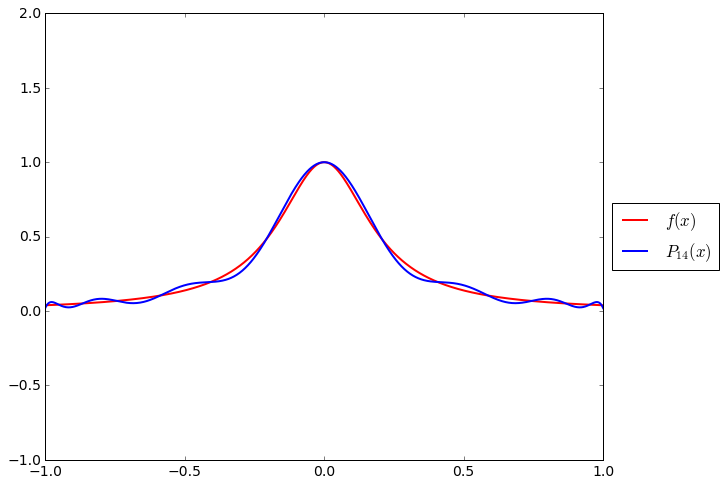

```python
plt.figure(figsize=(10, 8))
plt.plot(X, runge(X), 'r', label='$f(x)$', lw=2)
n = 15
x = np.cos((np.arange(n)*2+1) / (2*n) * np.pi)
F = divided_differences(x, runge(x))
plt.plot(X, evaluate(x, F, X), label='$P_{%d}(x)$' % (n-1), lw=2)
plt.axis([-1, 1, -1, 2]);
plt.legend(loc='center left', bbox_to_anchor=(1, .5)); plt.show()
```

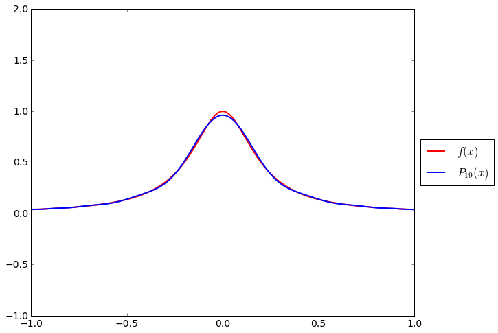

```python
plt.figure(figsize=(10, 8))
plt.plot(X, runge(X), 'r', label='$f(x)$', lw=2)
n = 20
x = np.cos((np.arange(n)*2+1) / (2*n) * np.pi)
F = divided_differences(x, runge(x))
plt.plot(X, evaluate(x, F, X), label='$P_{%d}(x)$' % (n-1), lw=2)
plt.axis([-1, 1, -1, 2]);
plt.legend(loc='center left', bbox_to_anchor=(1, .5)); plt.show()
```

### Интерполяция в форме Чебышева

Чебышев предложил свой способ построения интерполяционных полиномов

$$ C_N(x) = \sum\limits_{j=0}^N a_j \widetilde T_j(x) $$

где

$$ a_j = \frac{2}{N+1} \sum\limits_{k=0}^N f(x_k)\widetilde T_j(x_k) $$

Эта интерполяция основана на Лемме, отражающей свойства ортонормированности приведенных полиномов:

$$ \frac{2}{N+1} \sum\limits_{k=0}^N \widetilde T_j(x_k) \widetilde T_n(x) = \delta_{mn}, 0 \leq n, m \leq N. $$

### Задача 5

Построить интерполяционный многочлен в форме Чебышева $C_2(x)$ и привести его к виду $P_N(x) = a_0 + a_1x + ... + a_Nx^N$ для функции, заданной таблично

| $x$ | $x_0$ | $x_1$ | $x_2$ |
| --- | --- | --- | --- |
| $y$ | $2$ | $1$ | $3$ |

где $x_i$ - нули полинома Чебышева на отрезке $[-1, 1]$

Из условия задачи следует, что $N = 2$ . Найдем узлы сетки. Поскольку в задаче 3 узла, то полином Чебышева, на котором будет строиться интерполяция 3-го порядка. Найдем его нули. $$ x_k = \cos{\frac{2k+1}{2\cdot 3}\pi} , k = 0, 1, 2 $$

$$ x_0 = \cos{\frac{1}{2\cdot 3}\pi} = \frac{\sqrt{3}}{2} $$$$ x_1 = \cos{\frac{3}{2\cdot 3}\pi} = 0 $$$$ x_2 = \cos{\frac{5}{2\cdot 3}\pi} = -\frac{\sqrt{3}}{2} $$

Если подставлять следующие значения, то $k$, то нули начнут повторяться.

| $x$ | $\frac{\sqrt{3}}{2}$ | $0$ | $-\frac{\sqrt{3}}{2}$ |
| --- | --- | --- | --- |
| $y$ | $2$ | $1$ | $3$ |

Для построения интерполянта в форме Чебышева нужно сперва рассчитать коэффициенты $a_j$ Общая формула:

$$ a_j = \frac{2}{N+1} \sum\limits_{k=0}^N f(x_k)\widetilde T_j(x_k) $$

Тогда $$ a_0 = \frac{2}{3} (f_0\widetilde T_0(x_0) + f_1\widetilde T_0(x_1) + f_2\widetilde T_0(x_2)) = \frac{2}{3} (2 \cdot \frac{1}{\sqrt2} + 1\cdot \frac{1}{\sqrt 2}+3\cdot \frac{1}{\sqrt 2}) = 2\sqrt 2 $$

$$ a_1 = \frac{2}{3} (f_0\widetilde T_1(x_0) + f_1\widetilde T_1(x_1) + f_2\widetilde T_1(x_2)) = \frac{2}{3} (2 \cdot \frac{\sqrt 3}{2} + 1\cdot 0+3\cdot (-\frac{\sqrt 3}{2})) = - \frac{1}{\sqrt 3} $$$$ a_2 = \frac{2}{3} (f_0\widetilde T_2(x_0) + f_1\widetilde T_2(x_1) + f_2\widetilde T_2(x_2)) = \frac{2}{3} (2 \cdot (\frac{3}{2} - 1) + 1\cdot (2\cdot 0 - 1)+3\cdot (\frac{3}{2} - 1)) = 1 $$

Интерполяционный полином в форме Чебышева: $$ C_2(x) = a_0 \widetilde T_0(x) + a_1 \widetilde T_1(x) + a_2 \widetilde T_2(x) = 2\sqrt 2 \cdot \frac{1}{\sqrt 2} - \frac{1}{\sqrt 3} \cdot x + 2x^2 - 1 = 2x^2 - \frac{x}{\sqrt 3} + 1 $$

Если попробовать проверить этот результат и стандартным способом решать систему уравнений, $P_2(x) = a_0 + a_1x+ a_2 x^2$, то мы получим: $$ a_0 + a_1 \frac {\sqrt{3}}{2} + a_2\frac{3}{4} = 2 $$

$$ a_0 = 1 $$$$ a_0 - a_1 \frac {\sqrt{3}}{2} + a_2\frac{3}{4} = 3 $$

Соответственно $a_0 = 1, a_1 = -\frac{1}{\sqrt 3}, a_2 = 2$